# Notebook

**Investigating Regression Models**

Dr. Matthias Hölzl

```python
import numpy as np
import matplotlib.pyplot as plt
import seaborn as sns

sns.set_theme()
```

```python
rng = np.random.default_rng(42)
x = rng.uniform(size=(150, 1), low=0.0, high=10.0)
```

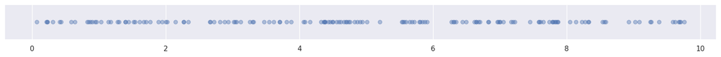

```python
plt.figure(figsize=(20, 1), frameon=False)
plt.yticks([], [])
plt.scatter(x, np.zeros_like(x), alpha=0.4);
```

```python
def lin(x):
    return 0.85 * x - 1.5
```

```python
def fun(x):
    return 2 * np.sin(x) + 0.1 * x ** 2 - 2
```

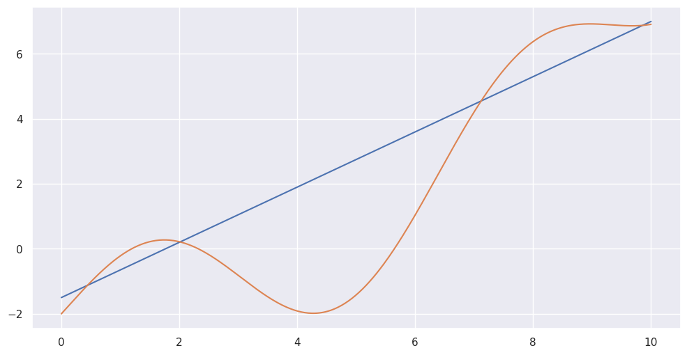

```python
x_plot = np.linspace(0, 10, 500)
plt.figure(figsize=(12, 6))
sns.lineplot(x=x_plot, y=lin(x_plot))
sns.lineplot(x=x_plot, y=fun(x_plot));
```

```python
def randomize(fun, x, scale=0.5):
    return fun(x) + rng.normal(size=x.shape, scale=scale)
```

```python
x_train, x_test = x[:100], x[100:]
```

```python
y_lin_train = lin(x_train).reshape(-1)
y_lin_test = lin(x_test).reshape(-1)
y_fun_train = fun(x_train.reshape(-1))
y_fun_test = fun(x_test).reshape(-1)
```

```python
y_rand_lin_train = randomize(lin, x_train).reshape(-1)
y_rand_lin_test = randomize(lin, x_test).reshape(-1)
y_rand_fun_train = randomize(fun, x_train.reshape(-1))
y_rand_fun_test = randomize(fun, x_test).reshape(-1)
```

```python
y_chaos_lin_train = randomize(lin, x_train, 1.5).reshape(-1)
y_chaos_lin_test = randomize(lin, x_test, 1.5).reshape(-1)
y_chaos_fun_train = randomize(fun, x_train, 1.5).reshape(-1)
y_chaos_fun_test = randomize(fun, x_test, 1.5).reshape(-1)
```

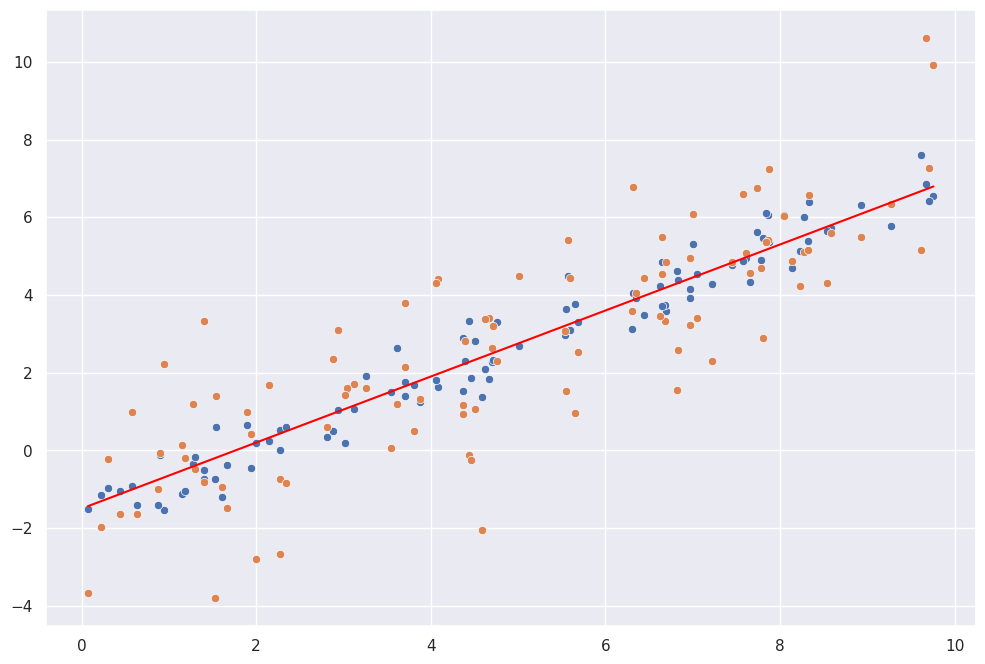

```python
fig, ax = plt.subplots(figsize=(12, 8))
sns.lineplot(x=x_train[:, 0], y=y_lin_train, color="red", ax=ax)
sns.scatterplot(x=x_train[:, 0], y=y_rand_lin_train, ax=ax)
sns.scatterplot(x=x_train[:, 0], y=y_chaos_lin_train, ax=ax);
```

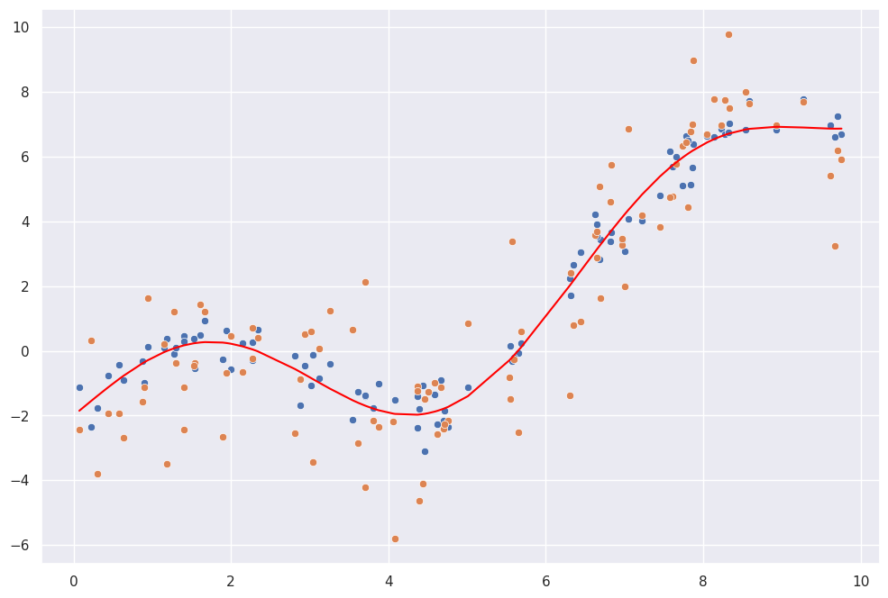

```python
fig, ax = plt.subplots(figsize=(12, 8))
sns.lineplot(x=x_train[:, 0], y=y_fun_train, color="red", ax=ax)
sns.scatterplot(x=x_train[:, 0], y=y_rand_fun_train, ax=ax)
sns.scatterplot(x=x_train[:, 0], y=y_chaos_fun_train, ax=ax);
```

## Linear Regression

```python
from sklearn.linear_model import LinearRegression
```

```python
lr_lin = LinearRegression()
lr_rand_lin = LinearRegression()
lr_chaos_lin = LinearRegression()
```

```python
lr_lin.fit(x_train, y_lin_train)
lr_rand_lin.fit(x_train, y_rand_lin_train)
lr_chaos_lin.fit(x_train, y_chaos_lin_train);
```

```python
print("lr_lin", lr_lin.coef_, lr_lin.intercept_)
print("lr_rand_lin", lr_rand_lin.coef_, lr_rand_lin.intercept_)
print("lr_chaos_lin", lr_chaos_lin.coef_, lr_chaos_lin.intercept_)
```

```
lr_lin [0.85] -1.4999999999999996
lr_rand_lin [0.87840412] -1.6636713907398777
lr_chaos_lin [0.86418078] -1.5745503093327176
```

```python
y_lr_lin_pred = lr_lin.predict(x_test)
y_lr_rand_lin_pred = lr_rand_lin.predict(x_test)
y_lr_chaos_lin_pred = lr_chaos_lin.predict(x_test)
```

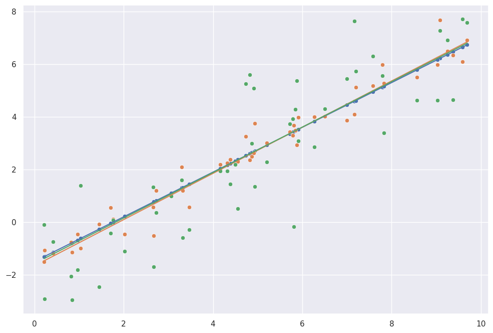

```python
fig, ax = plt.subplots(figsize=(12, 8))
sns.lineplot(x=x_test[:, 0], y=y_lr_lin_pred, ax=ax)
sns.scatterplot(x=x_test[:, 0], y=y_lin_test, ax=ax)

sns.lineplot(x=x_test[:, 0], y=y_lr_rand_lin_pred, ax=ax)
sns.scatterplot(x=x_test[:, 0], y=y_rand_lin_test, ax=ax)

sns.lineplot(x=x_test[:, 0], y=y_lr_chaos_lin_pred, ax=ax)
sns.scatterplot(x=x_test[:, 0], y=y_chaos_lin_test, ax=ax);
```

```python
from sklearn.metrics import mean_absolute_error, mean_squared_error
```

```python
mae_lin = mean_absolute_error(y_lin_test, y_lr_lin_pred)
mae_rand_lin = mean_absolute_error(y_rand_lin_test, y_lr_rand_lin_pred)
mae_chaos_lin = mean_absolute_error(y_chaos_lin_test, y_lr_chaos_lin_pred)

mse_lin = mean_squared_error(y_lin_test, y_lr_lin_pred)
mse_rand_lin = mean_squared_error(y_rand_lin_test, y_lr_rand_lin_pred)
mse_chaos_lin = mean_squared_error(y_chaos_lin_test, y_lr_chaos_lin_pred)

rmse_lin = np.sqrt(mean_squared_error(y_lin_test, y_lr_lin_pred))
rmse_rand_lin = np.sqrt(mean_squared_error(y_rand_lin_test, y_lr_rand_lin_pred))
rmse_chaos_lin = np.sqrt(mean_squared_error(y_chaos_lin_test, y_lr_chaos_lin_pred))

print(
    "No randomness:      "
    f"MAE = {mae_lin:.2f}, MSE = {mse_lin:.2f}, RMSE = {rmse_lin:.2f}"
)
print(
    "Some randomness:    "
    f"MAE = {mae_rand_lin:.2f}, MSE = {mse_rand_lin:.2f}, RMSE = {rmse_rand_lin:.2f}"
)
print(
    "Lots of randomness: "
    f"MAE = {mae_chaos_lin:.2f}, MSE = {mse_chaos_lin:.2f}, RMSE = {rmse_chaos_lin:.2f}"
)
```

```
No randomness:      MAE = 0.00, MSE = 0.00, RMSE = 0.00
Some randomness:    MAE = 0.34, MSE = 0.22, RMSE = 0.47
Lots of randomness: MAE = 1.20, MSE = 2.19, RMSE = 1.48
```

## Defining an Evaluation Function

```python
def evaluate_non_random_regressor(reg_type, f_y, *args, **kwargs):
    reg = reg_type(*args, **kwargs)

    y_train = f_y(x_train).reshape(-1)
    y_test = f_y(x_test).reshape(-1)

    reg.fit(x_train, y_train)
    y_pred = reg.predict(x_test)

    x_plot = np.linspace(0, 10, 500).reshape(-1, 1)
    fig, ax = plt.subplots(figsize=(12, 6))
    sns.lineplot(x=x_plot[:, 0], y=reg.predict(x_plot), ax=ax)
    sns.lineplot(x=x_plot[:, 0], y=f_y(x_plot[:, 0]), ax=ax)
    sns.scatterplot(x=x_train[:, 0], y=y_train, ax=ax)
    plt.show()

    mae = mean_absolute_error(y_test, y_pred)
    mse = mean_squared_error(y_test, y_pred)
    rmse = np.sqrt(mean_squared_error(y_test, y_pred))
    print(
        "\nNo randomness:      " f"MAE = {mae:.2f}, MSE = {mse:.2f}, RMSE = {rmse:.2f}"
    )

    return reg
```

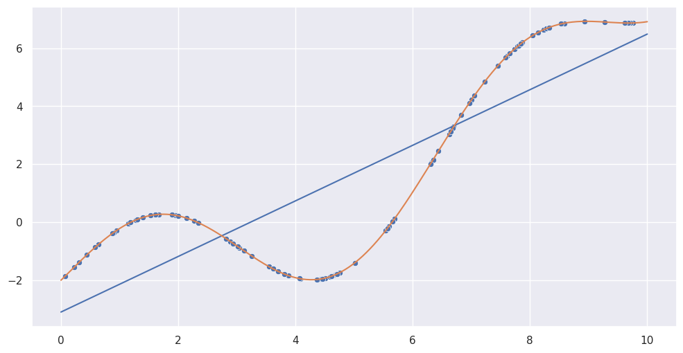

```
No randomness:      MAE = 1.73, MSE = 3.78, RMSE = 1.94
```

```python
evaluate_non_random_regressor(LinearRegression, fun);
```

### Underfitting

Underfitting occurs when the model is not able to fit the training data.

```python
def plot_graphs(f_y, reg, reg_rand, reg_chaos, y_train, y_rand_test, y_chaos_test):
    x_plot = np.linspace(0, 10, 500).reshape(-1, 1)
    fig, ax = plt.subplots(figsize=(12, 8))
    sns.lineplot(x=x_plot[:, 0], y=reg.predict(x_plot), ax=ax)
    sns.scatterplot(x=x_train[:, 0], y=y_train, ax=ax)

    sns.lineplot(x=x_plot[:, 0], y=reg_rand.predict(x_plot), ax=ax)
    sns.scatterplot(x=x_test[:, 0], y=y_rand_test, ax=ax)

    sns.lineplot(x=x_plot[:, 0], y=reg_chaos.predict(x_plot), ax=ax)
    sns.scatterplot(x=x_test[:, 0], y=y_chaos_test, ax=ax)

    sns.lineplot(x=x_plot[:, 0], y=f_y(x_plot[:, 0]), ax=ax)
    plt.show()
```

```python
def print_evaluation(y_test, y_pred, y_rand_test, y_rand_pred, y_chaos_test, y_chaos_pred):
    mae = mean_absolute_error(y_test, y_pred)
    mae_rand = mean_absolute_error(y_rand_test, y_rand_pred)
    mae_chaos = mean_absolute_error(y_chaos_test, y_chaos_pred)

    mse = mean_squared_error(y_test, y_pred)
    mse_rand = mean_squared_error(y_rand_test, y_rand_pred)
    mse_chaos = mean_squared_error(y_chaos_test, y_chaos_pred)

    rmse = np.sqrt(mean_squared_error(y_test, y_pred))
    rmse_rand = np.sqrt(mean_squared_error(y_rand_test, y_rand_pred))
    rmse_chaos = np.sqrt(mean_squared_error(y_chaos_test, y_chaos_pred))

    print(
        "\nNo randomness:      " f"MAE = {mae:.2f}, MSE = {mse:.2f}, RMSE = {rmse:.2f}"
    )
    print(
        "Some randomness:    "
        f"MAE = {mae_rand:.2f}, MSE = {mse_rand:.2f}, RMSE = {rmse_rand:.2f}"
    )
    print(
        "Lots of randomness: "
        f"MAE = {mae_chaos:.2f}, MSE = {mse_chaos:.2f}, RMSE = {rmse_chaos:.2f}"
    )
```

```python
def evaluate_regressor(reg_type, f_y, *args, **kwargs):
    reg = reg_type(*args, **kwargs)
    reg_rand = reg_type(*args, **kwargs)
    reg_chaos = reg_type(*args, **kwargs)

    y_train = f_y(x_train).reshape(-1)
    y_test = f_y(x_test).reshape(-1)
    y_pred = reg.fit(x_train, y_train).predict(x_test)

    y_rand_train = randomize(f_y, x_train).reshape(-1)
    y_rand_test = randomize(f_y, x_test).reshape(-1)
    y_rand_pred = reg_rand.fit(x_train, y_rand_train).predict(x_test)

    y_chaos_train = randomize(f_y, x_train, 1.5).reshape(-1)
    y_chaos_test = randomize(f_y, x_test, 1.5).reshape(-1)
    y_chaos_pred = reg_chaos.fit(x_train, y_chaos_train).predict(x_test)

    plot_graphs(f_y, reg, reg_rand, reg_chaos, y_train, y_rand_test, y_chaos_test)
    print_evaluation(y_test, y_pred, y_rand_test, y_rand_pred, y_chaos_test, y_chaos_pred)
```

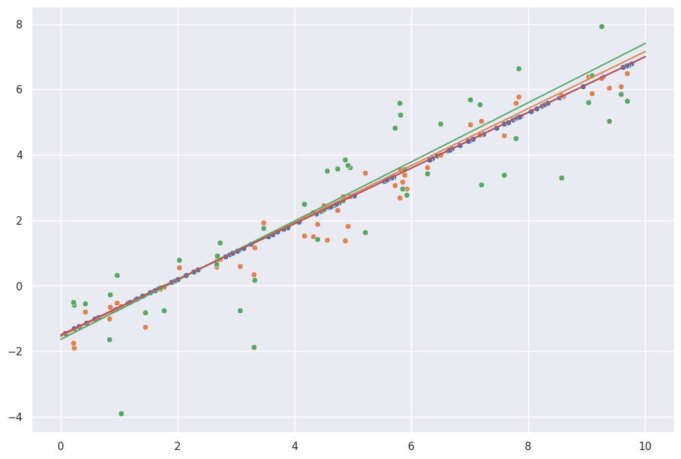

```
No randomness:      MAE = 0.00, MSE = 0.00, RMSE = 0.00
Some randomness:    MAE = 0.37, MSE = 0.23, RMSE = 0.48
Lots of randomness: MAE = 1.00, MSE = 1.53, RMSE = 1.24
```

```python
evaluate_regressor(LinearRegression, lin)
```

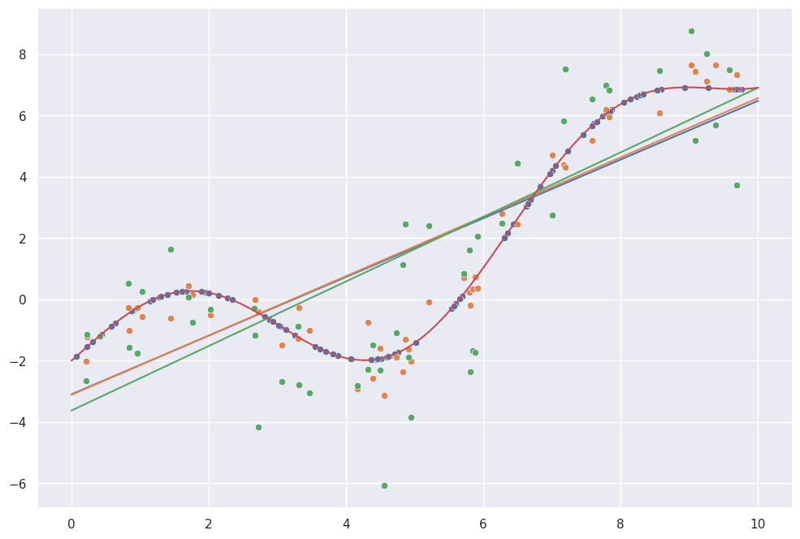

```
No randomness:      MAE = 1.73, MSE = 3.78, RMSE = 1.94
Some randomness:    MAE = 1.73, MSE = 4.10, RMSE = 2.02
Lots of randomness: MAE = 2.21, MSE = 7.00, RMSE = 2.65
```

```python
evaluate_regressor(LinearRegression, fun)
```

## Stochastic Gradient Descent

```python
from sklearn.linear_model import SGDRegressor
```

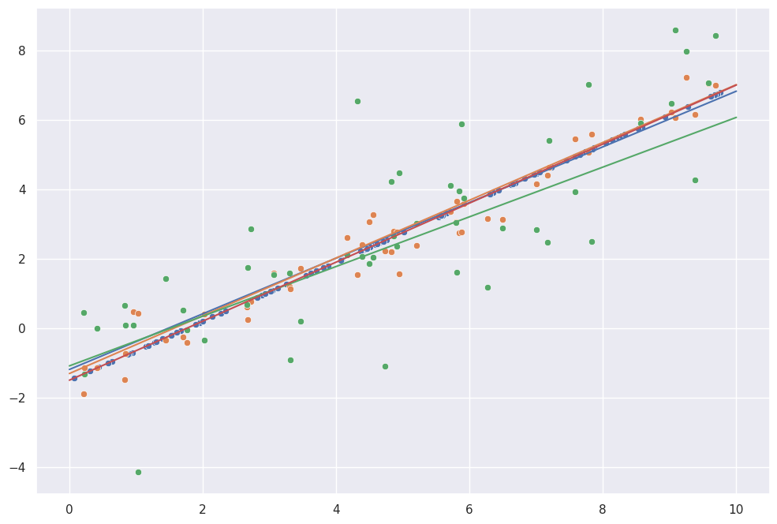

```
No randomness:      MAE = 0.13, MSE = 0.02, RMSE = 0.15
Some randomness:    MAE = 0.41, MSE = 0.27, RMSE = 0.52
Lots of randomness: MAE = 1.26, MSE = 2.70, RMSE = 1.64
```

```python
evaluate_regressor(SGDRegressor, lin)
```

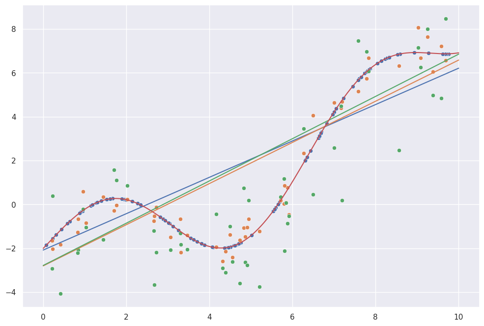

```
No randomness:      MAE = 1.76, MSE = 4.26, RMSE = 2.06
Some randomness:    MAE = 1.70, MSE = 4.03, RMSE = 2.01
Lots of randomness: MAE = 2.32, MSE = 7.50, RMSE = 2.74
```

```python
evaluate_regressor(SGDRegressor, fun)
```

### Unnormalized Data

Stochastic gradient descent can sometimes run into trouble when different features are of different magnitudes.

## Nearest Neighbors

[figure not shown]

```python
from sklearn.neighbors import KNeighborsRegressor
```

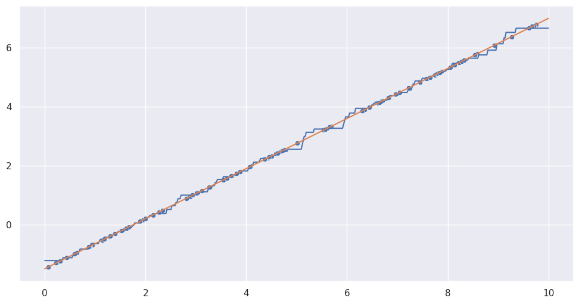

```
No randomness:      MAE = 0.08, MSE = 0.01, RMSE = 0.11
```

```python
evaluate_non_random_regressor(KNeighborsRegressor, lin);
```

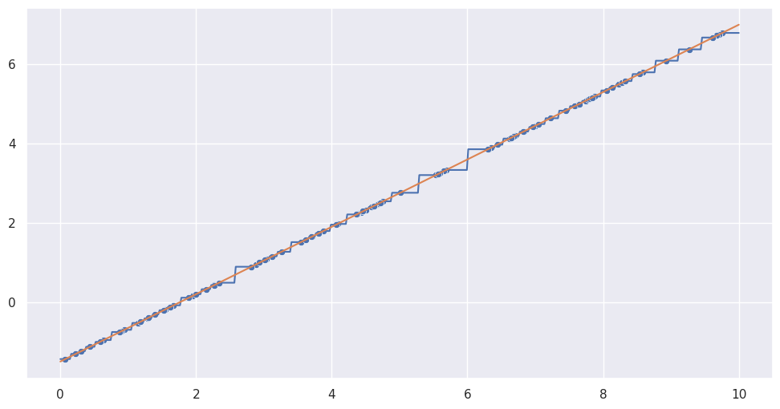

```
No randomness:      MAE = 0.05, MSE = 0.01, RMSE = 0.07
```

```python
evaluate_non_random_regressor(KNeighborsRegressor, lin, n_neighbors=1);
```

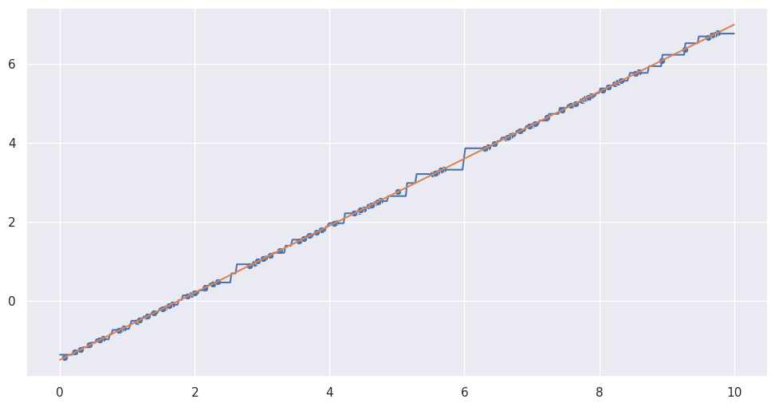

```
No randomness:      MAE = 0.06, MSE = 0.01, RMSE = 0.07
```

```python
evaluate_non_random_regressor(KNeighborsRegressor, lin, n_neighbors=2);
```

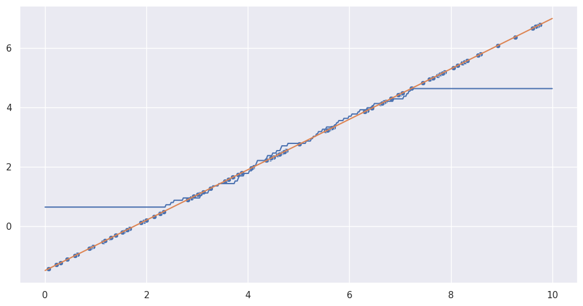

```
No randomness:      MAE = 0.60, MSE = 0.84, RMSE = 0.92
```

```python
evaluate_non_random_regressor(KNeighborsRegressor, lin, n_neighbors=50);
```

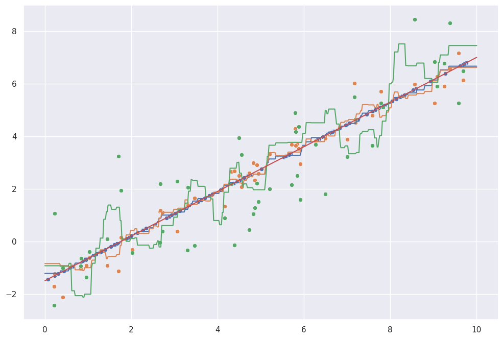

```
No randomness:      MAE = 0.08, MSE = 0.01, RMSE = 0.11
Some randomness:    MAE = 0.39, MSE = 0.25, RMSE = 0.50
Lots of randomness: MAE = 1.17, MSE = 1.91, RMSE = 1.38
```

```python
evaluate_regressor(KNeighborsRegressor, lin)
```

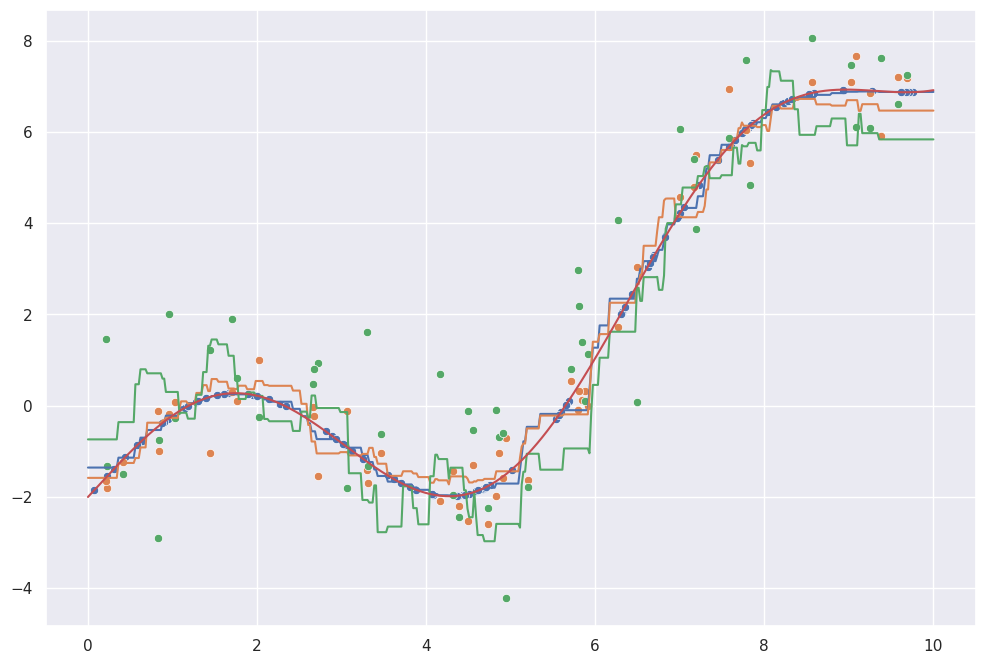

```
No randomness:      MAE = 0.17, MSE = 0.07, RMSE = 0.27
Some randomness:    MAE = 0.52, MSE = 0.39, RMSE = 0.62
Lots of randomness: MAE = 1.47, MSE = 3.02, RMSE = 1.74
```

```python
evaluate_regressor(KNeighborsRegressor, fun)
```

## Training Decision Trees

- (Conceptually) build a nested `if`-`then`-`else` statement
- Each test compares one feature against a value
- Minimize some *loss function* (e.g., mean squared error)

```
if feature_1 < 1.2:
    if feature_2 < 3.0:
        if feature_1 < 0.2:
            return 25_324
        else:
            return 17_145
    else:
        ...
else:
    ...
```

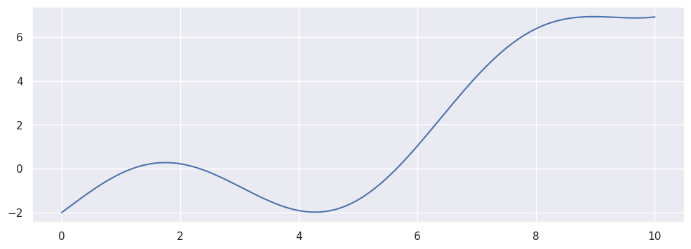

```python
x_plot = np.linspace(0, 10, 500)
plt.figure(figsize=(12, 4))
sns.lineplot(x=x_plot, y=fun(x_plot));
```

```python
from sklearn.metrics import mean_squared_error
x_plot = np.linspace(0, 10, 500)
y_plot = np.ones_like(x_plot) * 1.5
print(mean_squared_error(fun(x_plot), y_plot))
```

```
11.044163958007436
```

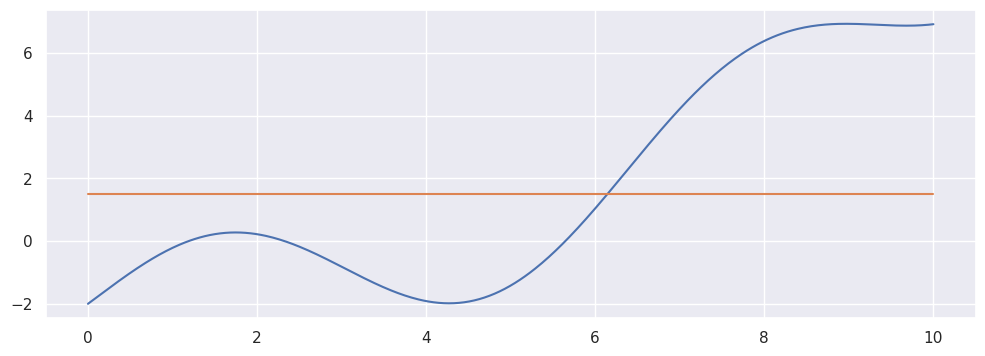

```python
plt.figure(figsize=(12, 4))
sns.lineplot(x=x_plot, y=fun(x_plot))
sns.lineplot(x=x_plot, y=y_plot);
```

```python
def approx(x):
    if x < 6.2:
        return -0.5
    else:
        return 5.5
```

```python
approx(4), approx(8)
```

```
(-0.5, 5.5)
```

```python
list(map(approx, np.arange(4, 10)))
```

```
[-0.5, -0.5, -0.5, 5.5, 5.5, 5.5]
```

```python
x_plot = np.linspace(0, 10, 500)
y_plot = list(map(approx, x_plot))
print(mean_squared_error(fun(x_plot), y_plot))
```

```
1.4757448667093518
```

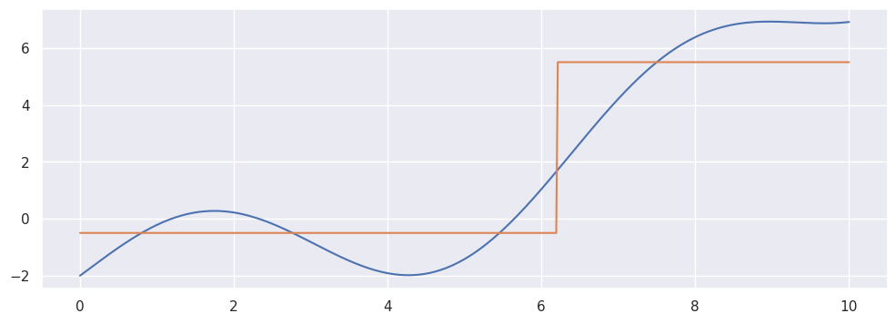

```python
plt.figure(figsize=(12, 4))
sns.lineplot(x=x_plot, y=fun(x_plot))
sns.lineplot(x=x_plot, y=y_plot);
```

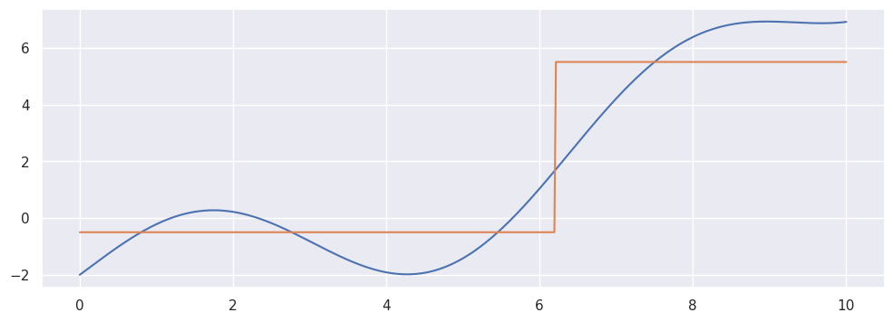

```python
plt.figure(figsize=(12, 4))
sns.lineplot(x=x_plot, y=fun(x_plot));
sns.lineplot(x=x_plot, y=np.select([x_plot<6.2, x_plot>=6.2], [-0.5, 5.5]));
```

## Disadvantages

- Very prone to overfitting
- Sensitive to unbalanced data sets
- Only discrete predictions with axis-aligned boundaries
- Unstable when training data changes (tree may change completely when a single item is added)

```python
from sklearn.tree import DecisionTreeRegressor
```

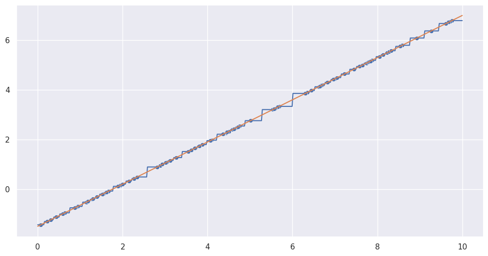

```
No randomness:      MAE = 0.05, MSE = 0.01, RMSE = 0.07
```

```python
evaluate_non_random_regressor(DecisionTreeRegressor, lin);
```

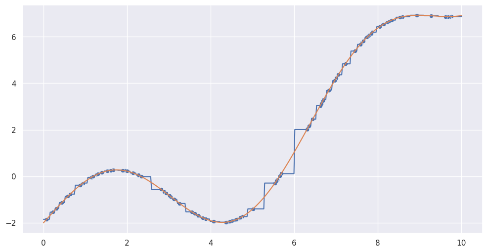

```
No randomness:      MAE = 0.10, MSE = 0.03, RMSE = 0.17
```

```python
evaluate_non_random_regressor(DecisionTreeRegressor, fun);
```

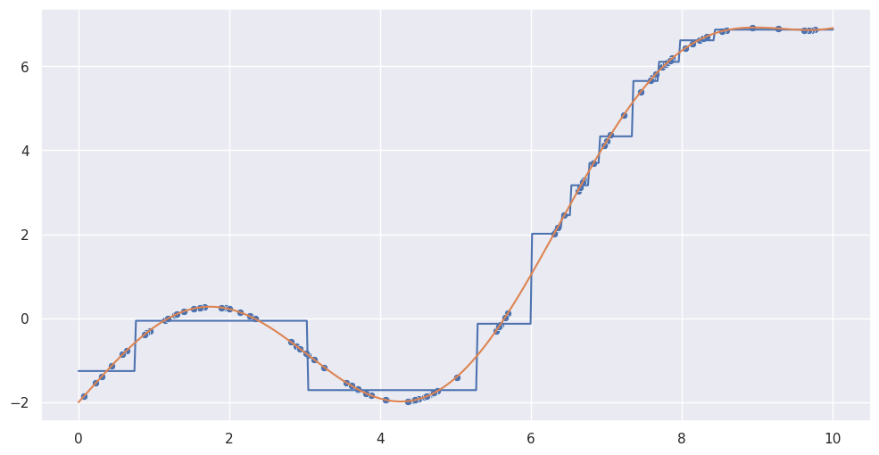

```
No randomness:      MAE = 0.27, MSE = 0.13, RMSE = 0.35
```

```python
evaluate_non_random_regressor(DecisionTreeRegressor, fun, max_depth=4);
```

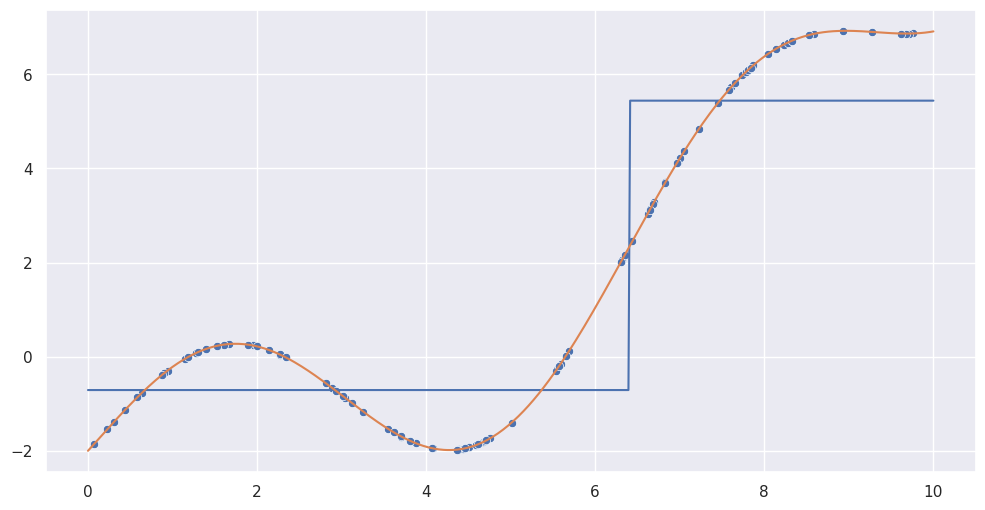

```
No randomness:      MAE = 0.97, MSE = 1.22, RMSE = 1.11
```

```python
dt1 = evaluate_non_random_regressor(DecisionTreeRegressor, fun, max_depth=1);
```

```python
from sklearn.tree import plot_tree;
```

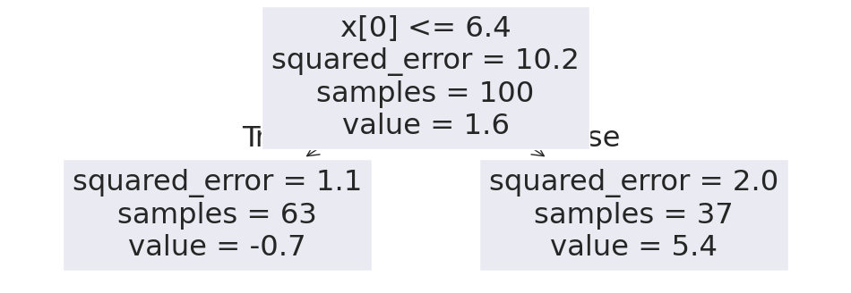

```python
fig, ax = plt.subplots(figsize=(12, 4))
plot_tree(dt1, ax=ax, precision=1);
```

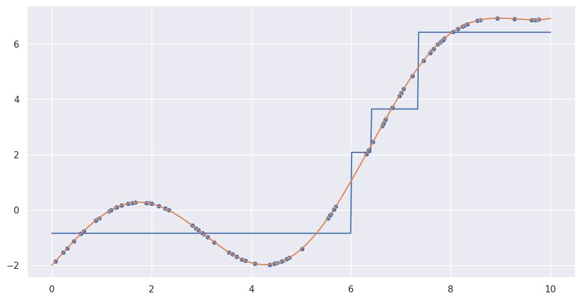

```
No randomness:      MAE = 0.74, MSE = 0.69, RMSE = 0.83
```

```python
dt2 = evaluate_non_random_regressor(DecisionTreeRegressor, fun, max_depth=2);
```

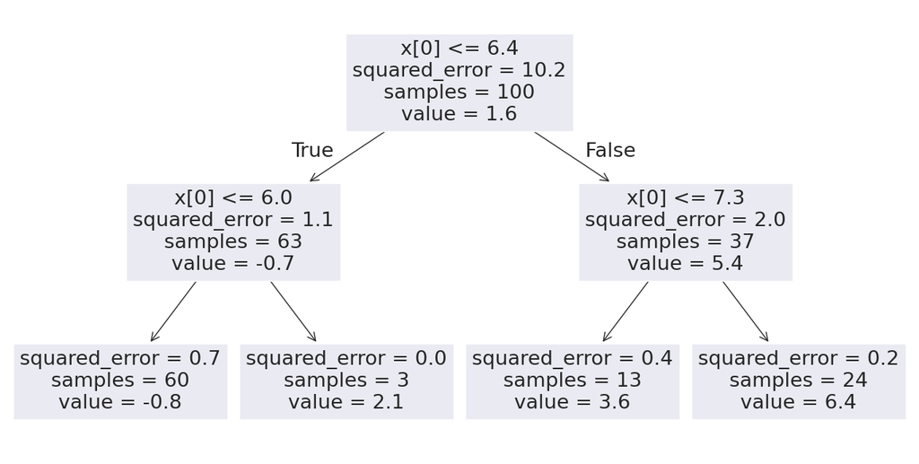

```python
fig, ax = plt.subplots(figsize=(16, 8))
plot_tree(dt2, ax=ax, precision=1);
```

```python
def plot_regressions(regressors, f_y):
    y_train = f_y(x_train).reshape(-1)

    x_plot = np.linspace(0, 10, 500).reshape(-1, 1)
    fig, ax = plt.subplots(figsize=(12, 6))
    sns.lineplot(x=x_plot[:, 0], y=f_y(x_plot[:, 0]), ax=ax)
    sns.scatterplot(x=x_train[:, 0], y=y_train, ax=ax)
    for reg in regressors:
        sns.lineplot(x=x_plot[:, 0], y=reg.predict(x_plot), ax=ax)
    plt.show()
```

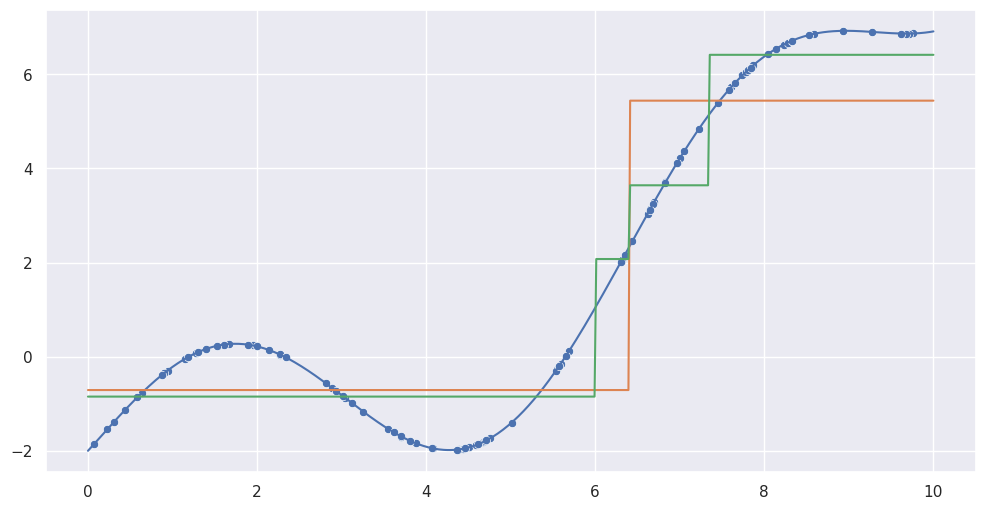

```python
plot_regressions([dt1, dt2], fun);
```

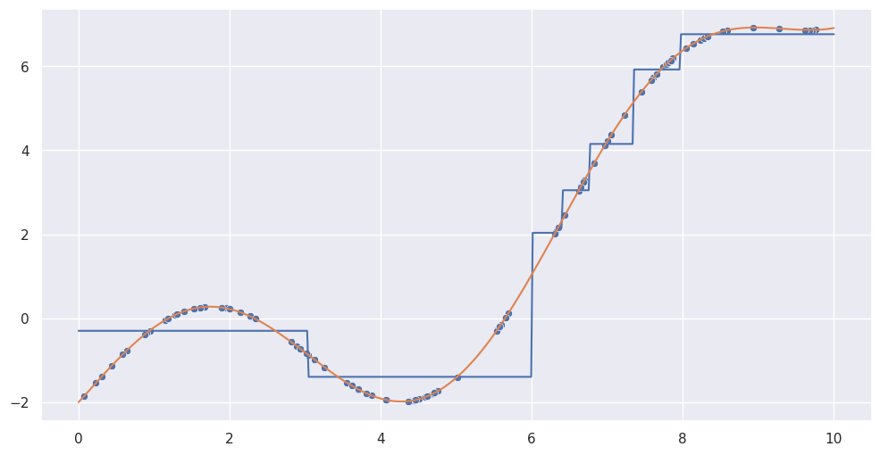

```
No randomness:      MAE = 0.52, MSE = 0.61, RMSE = 0.78
```

```python
dt3 = evaluate_non_random_regressor(DecisionTreeRegressor, fun, max_depth=3);
```

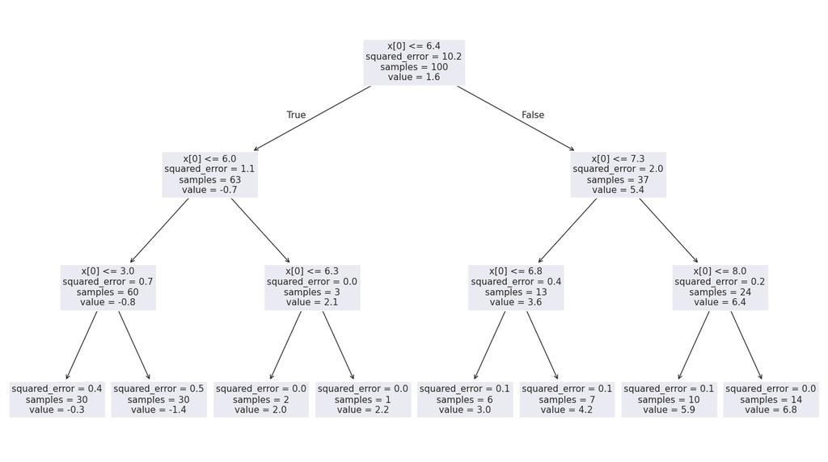

```python
fig, ax = plt.subplots(figsize=(18, 10))
plot_tree(dt3, ax=ax, precision=1);
```

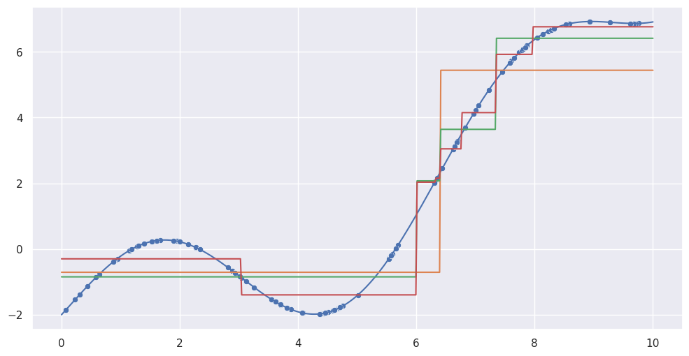

```python
plot_regressions([dt1, dt2, dt3], fun);
```